# RMarkdown Assignment

Brian Busby

2/7/2020

## Thesis Research

I am investigating the effects of roads on vital rates and movement behavior in Barn Owls. With Idaho currently home to the highest road mortality rates for Barn Owls worldwide its critical to understand how Barn Owls are reacting to roads to better mitigate the effects on their population. I am using GPS dataloggers to collect fine-scale movements on Barn Owls in relation to roads. Specifically I want to see if owls are responding to roads (are they changing flight speed, altitude, or direction as they encounter roads) and if they are attracted to roadside verge as hunting habitat compared to other suitable hunting areas within their home ranges.

## Study Area

My study area is mostly in Canyon County, Idaho. Canyon county is a great place to ask these questions because **A)** it has over 300 Barn OWl nest boxes that we have access to, giving us a population which we can easily study, **B)** its located in southern Idaho, which currently has the highest rates of road mortality for Barn Owls globally, and **C)** it is mosaic of different landcover types, ranging from urban, commercial, and industrial areas to rural agriculture and shrub-steppe ecosystems.

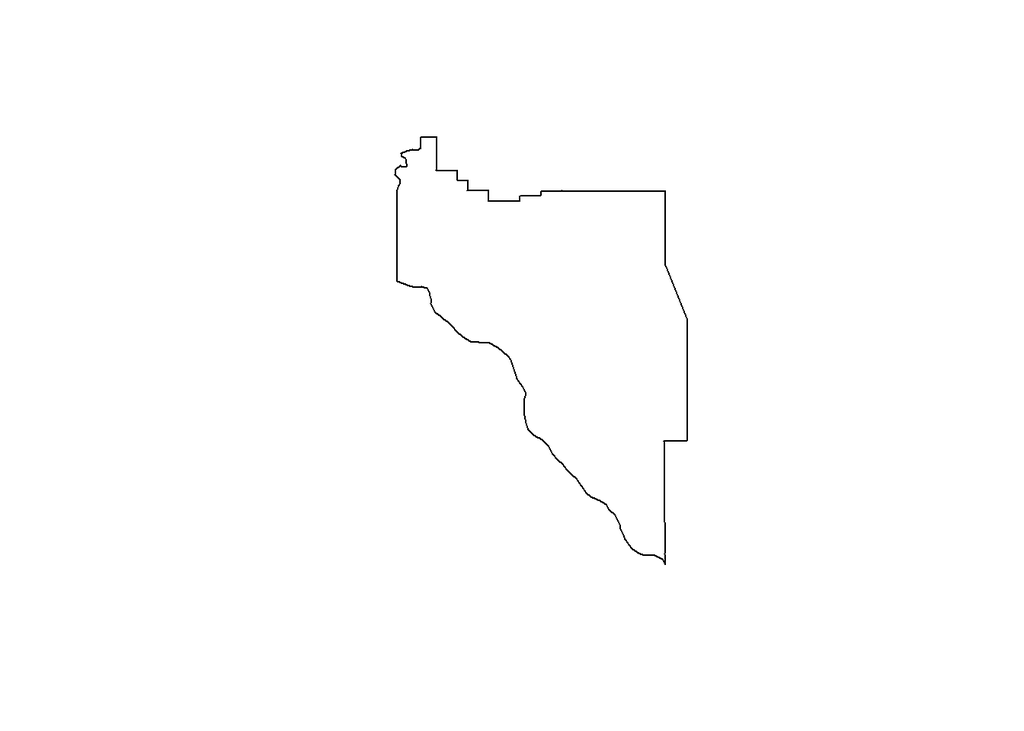

```r
#first we grab the county shape files of the US
us<-getData('GADM', country='USA', level=2)

#subset it to Idaho
Idaho<-subset(us,NAME_1=="Idaho")

#and subset it to Canyon County
canco<-subset(Idaho,NAME_2=="Canyon")

#voila, here is my study area
plot(canco)
```

## Mapping Attributes

Now to map an attribute. I decided that the census data is pretty uninformative for my research. One. I’m more interested in one the land looks like, not what the people in that land have going on in their lives. Secondly, if I’m only interested in one county then the attribute data from the census will all just be single values for each variable, which wouldn’t really map very well because theres nothing to compare it to. So I chose the difficult task of trying to overlay the NLCD land cover data over the shape of my map. This code makes it look easy but this took about 5 hours to figure out and multiple workshop sessions with more seasoned grad students…

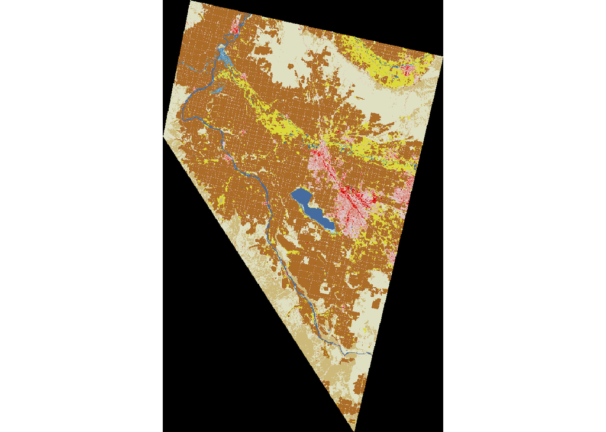

```r
#first lets load in the NLCD data in .tif form. To find the data you have to download it off MRLC.gov and then extract the zip file. As it turns out they don't provide you the information in .tif form, rather its a raster extension which I couldn't get to open in R. Unfortunately I had to switch over to the enemy and open the file in ArcMap which I used to clip the file down to a smaller size that still encompassed Canyon County and then export it as a .tif. Since I've never worked in Arcmap this was quite time-consuming. Now lets load up that .tif

NLCD<-raster("bingbong.tif")
plot(NLCD)
```

```r
#wow looks pretty good, now lets see what projection are Canyon County data is in...

proj4string(canco)
```

```
## [1] "+proj=longlat +datum=WGS84 +no_defs +ellps=WGS84 +towgs84=0,0,0"
```

```r
#is this the same as our NLCD tif?

proj4string(NLCD)
```

```
## [1] "+proj=aea +lat_1=29.5 +lat_2=45.5 +lat_0=23 +lon_0=-96 +x_0=0 +y_0=0 +datum=WGS84 +units=m +no_defs +ellps=WGS84 +towgs84=0,0,0"
```

```r
#no...so we have to reproject it...

canco.2<-spTransform(canco, CRS(projargs = "+proj=aea +lat_1=29.5 +lat_2=45.5 +lat_0=23 +lon_0=-96 +x_0=0 +y_0=0 +datum=WGS84 +units=m +no_defs +ellps=WGS84 +towgs84=0,0,0" ))

#nice, but are they the same?

setdiff(as.character(crs(NLCD)), as.character(crs(canco.2)))
```

```
## character(0)
```

```r
#they are! now lets try an overlay to visually verify

plot(NLCD)
```

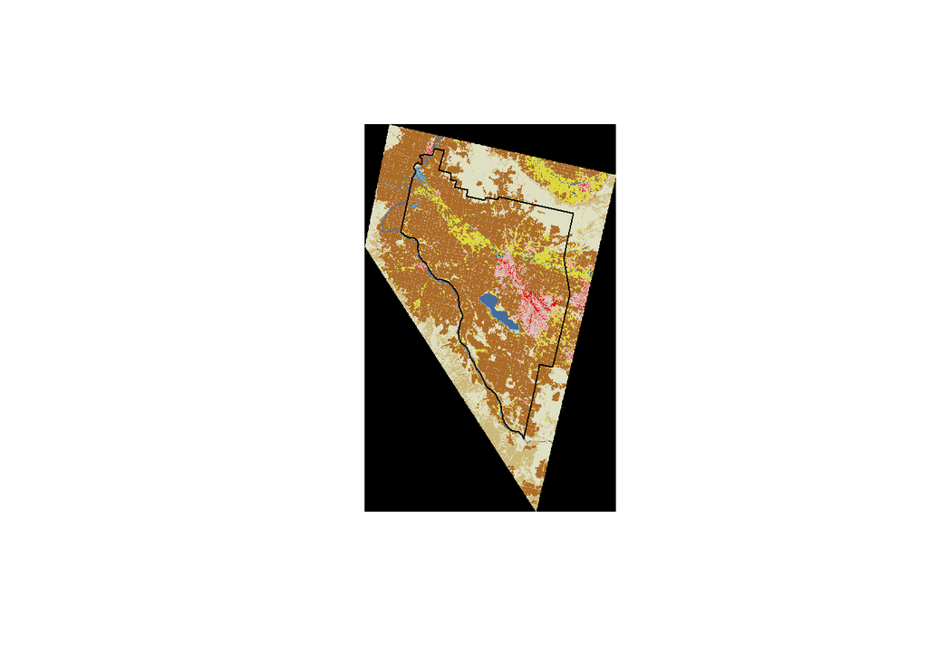

```r
plot(canco.2, add=TRUE)
```

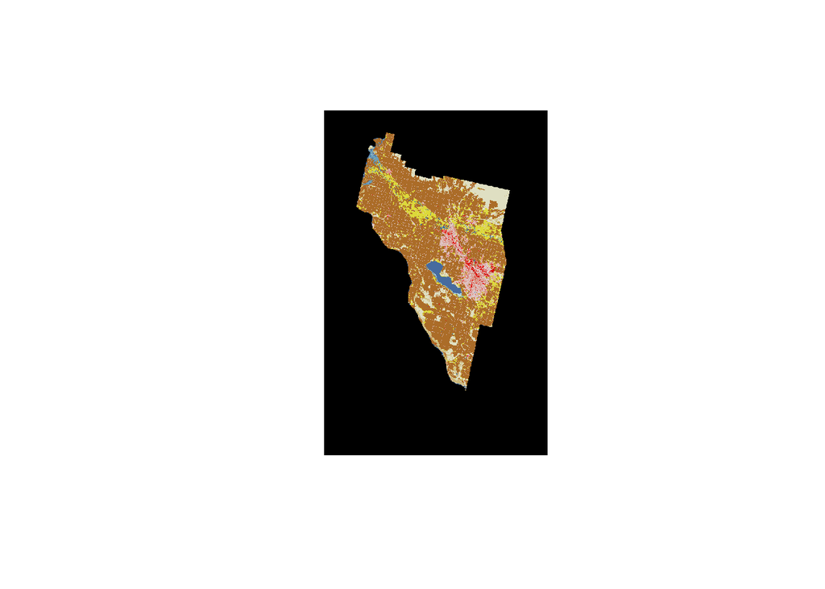

```r
#amazing, now lets clip our NLCD data down to just the county size...

canco.3<-mask(NLCD,canco.2)

#but did it work?

plot(canco.3)
```

```r
#I've never been so happy in my whole life
```

## Plotting Differently

Now its time to look at some of the attributes of our data. I think the best way to do this would be to utilize a landscape metrics package so we can look at compostion, connectivity, etc.

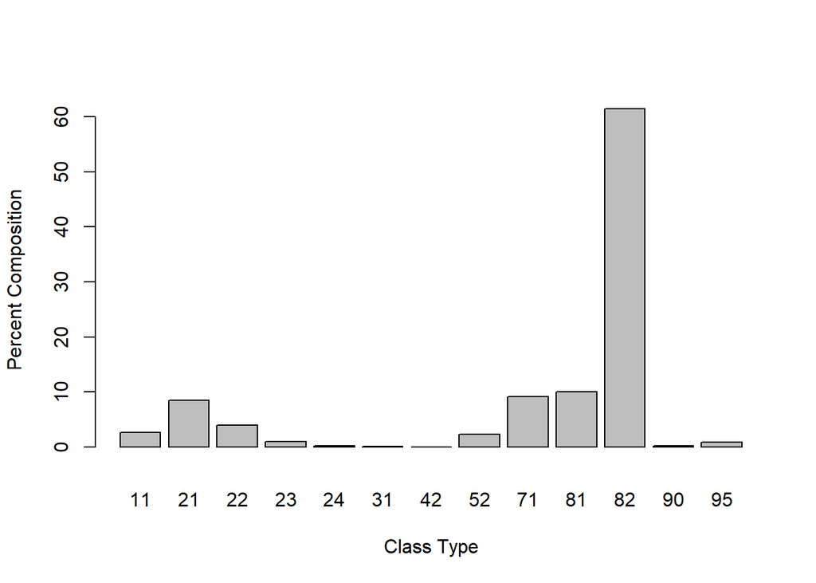

```r
library(landscapemetrics)

#first lets look at the composition of the landscape.

landcomp<-lsm_c_pland(canco.3,directions = 8)

barplot(landcomp$value~landcomp$class,
        xlab = "Class Type",
        ylab = "Percent Composition")
```

```r
#this is tough to interpret when you don't know what the integer values translate to for the classes. I haven't figured out how to do that yet. Let me just say that 82 is cultivated crop and that makes a lot of sense.

#this is a measure of the eveness of the landscape... seems like its not super even, indicating domination by a land class, which would be 82
lsm_l_shei(canco.3)
```

```
## # A tibble: 1 x 6
##   layer level     class    id metric value
##   <int> <chr>     <int> <int> <chr>  <dbl>
## 1     1 landscape    NA    NA shei   0.536
```

```r
lsm_c_pd(canco.3, directions = 8)
```

```
## # A tibble: 13 x 6
##    layer level class    id metric    value
##    <int> <chr> <int> <int> <chr>     <dbl>
##  1     1 class    11    NA pd     0.438
##  2     1 class    21    NA pd     3.95
##  3     1 class    22    NA pd     5.73
##  4     1 class    23    NA pd     2.01
##  5     1 class    24    NA pd     0.690
##  6     1 class    31    NA pd     0.147
##  7     1 class    42    NA pd     0.000635
##  8     1 class    52    NA pd     0.453
##  9     1 class    71    NA pd     0.890
## 10     1 class    81    NA pd     1.66
## 11     1 class    82    NA pd     1.49
## 12     1 class    90    NA pd     0.0959
## 13     1 class    95    NA pd     0.358
```

```r
#this is telling us the average number of patches for each class per 100 ha... a good metric of connectivity

lsm_l_contag(canco.3)
```

```
## # A tibble: 1 x 6
##   layer level     class    id metric value
##   <int> <chr>     <int> <int> <chr>  <dbl>
## 1     1 landscape    NA    NA contag  63.5
```

```r
#This is a pretty high value for contagion, which ranges from 0 to 100. It tells us that our landscape is very "clumpy" meaning that patch size is larger and there's more connectivity
```

## What I learned

I learned a lot. First and foremost that *nothing* is easy in R. But in regards to the data, the visual map is nice in that you can really get a feel for the layout of the landscape and connectivity of it all, as well as the dominance of the cultivated crop land cover. But the actual stats on the attributes are quite telling as well. Actual percent composition numbers paint a great picture, and when you combine that with connectivity metrices like patch density and contagion you get a feel for how the landscape is shaped at a smaller scale. I think both are vital, but the actual analysis and number crunching will actually come from the latter and might be able to be expressed through the former.